# 2024 Presidential Election: Polling Averages

Author

Dylan Kehm

Published

March 18, 2026

# 2024 Presidential Election: Polling Averages

This notebook analyzes national polling averages for the 2024 U.S. Presidential Election between Vice President Kamala Harris and former President Donald Trump, covering the period from July 22, 2024 through Election Day (November 5, 2024).

The data is sourced from FiveThirtyEight’s published national polling averages, which aggregate individual surveys weighted by pollster quality, recency, and sample size.

## Setup

```python
import pandas as pd
import matplotlib.pyplot as plt
import matplotlib.ticker as mticker
import matplotlib.dates as mdates
import numpy as np
import io

# ── Inline data (no external file needed) ─────────────────────────────────────
raw = """date,harris,trump,event
2024-07-22,44.1,46.8,
2024-07-24,44.3,46.6,
2024-07-26,44.9,46.2,Harris enters race
2024-07-28,45.2,46.0,
2024-07-30,45.5,45.9,
2024-08-01,45.7,45.8,
2024-08-05,46.1,45.6,
2024-08-10,46.4,45.4,
2024-08-15,46.6,45.3,
2024-08-19,47.0,45.1,DNC Convention
2024-08-22,47.2,45.0,
2024-08-26,47.1,45.2,
2024-08-30,46.9,45.4,
2024-09-05,46.7,45.5,
2024-09-10,47.1,45.3,Presidential Debate
2024-09-14,47.4,45.1,
2024-09-18,47.2,45.2,
2024-09-22,46.9,45.5,
2024-09-26,46.8,45.6,
2024-09-30,46.6,45.7,
2024-10-05,46.5,45.8,
2024-10-10,46.4,46.0,
2024-10-14,46.3,46.1,VP Debate
2024-10-18,46.2,46.2,
2024-10-22,46.1,46.4,
2024-10-26,46.0,46.6,
2024-10-30,45.9,46.7,
2024-11-01,45.8,46.8,
2024-11-04,45.7,46.9,
2024-11-05,47.5,48.9,Election Day"""

df = pd.read_csv(io.StringIO(raw), parse_dates=["date"])

# Color palette
BLUE = "#2166ac"   # Harris
RED  = "#d6604d"   # Trump
GRAY = "#888888"
BG   = "#f9f9f9"

print(f"Loaded {len(df)} rows from {df['date'].min().date()} to {df['date'].max().date()}")
df.head()
```

```
Loaded 30 rows from 2024-07-22 to 2024-11-05
```

|  | date | harris | trump | event |
| --- | --- | --- | --- | --- |
| 0 | 2024-07-22 | 44.1 | 46.8 | NaN |
| 1 | 2024-07-24 | 44.3 | 46.6 | NaN |
| 2 | 2024-07-26 | 44.9 | 46.2 | Harris enters race |
| 3 | 2024-07-28 | 45.2 | 46.0 | NaN |
| 4 | 2024-07-30 | 45.5 | 45.9 | NaN |

## Annotated Time-Series Chart

This chart shows both candidates’ national polling averages over time, with annotations marking the three most consequential moments of the race.

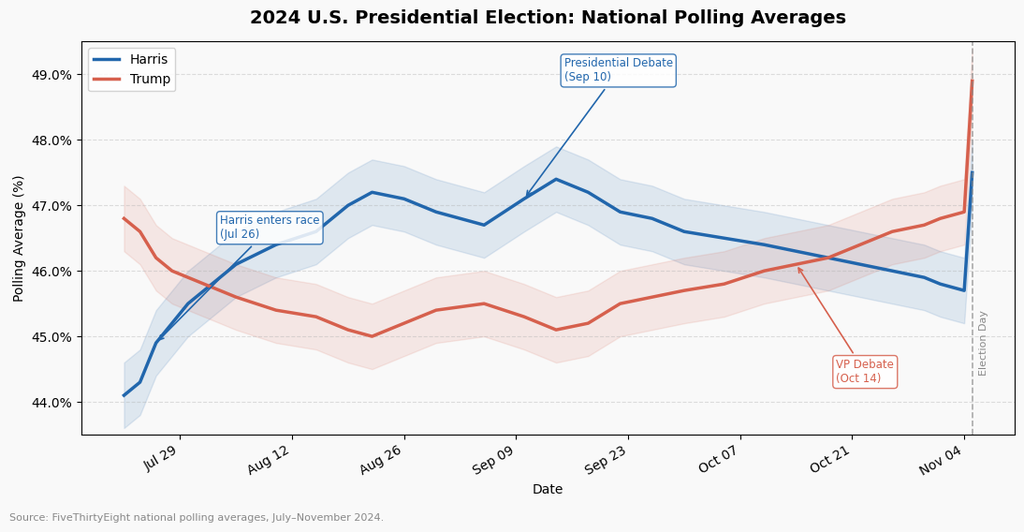

```python
fig, ax = plt.subplots(figsize=(11, 5.5))
fig.patch.set_facecolor(BG)
ax.set_facecolor(BG)

# ── Lines ──────────────────────────────────────────────────────────────────────
ax.plot(df["date"], df["harris"], color=BLUE, lw=2.5, label="Harris")
ax.plot(df["date"], df["trump"],  color=RED,  lw=2.5, label="Trump")

# ── Shaded uncertainty band (±0.5 pp) ─────────────────────────────────────────
ax.fill_between(df["date"], df["harris"] - 0.5, df["harris"] + 0.5,
                color=BLUE, alpha=0.12)
ax.fill_between(df["date"], df["trump"]  - 0.5, df["trump"]  + 0.5,
                color=RED,  alpha=0.12)

# ── Annotations ───────────────────────────────────────────────────────────────
annotations = [
    {"label": "Harris enters race\n(Jul 26)",  "date": "2024-07-26", "candidate": "harris", "dy":  1.6, "dx": 8},
    {"label": "Presidential Debate\n(Sep 10)", "date": "2024-09-10", "candidate": "harris", "dy":  1.8, "dx": 5},
    {"label": "VP Debate\n(Oct 14)",            "date": "2024-10-14", "candidate": "trump",  "dy": -1.8, "dx": 5},
]

for ann in annotations:
    row = df[df["date"] == ann["date"]].iloc[0]
    y   = row[ann["candidate"]]
    col = BLUE if ann["candidate"] == "harris" else RED
    ax.annotate(
        ann["label"],
        xy=(row["date"], y),
        xytext=(row["date"] + pd.Timedelta(days=ann["dx"]), y + ann["dy"]),
        fontsize=8.5, color=col,
        arrowprops=dict(arrowstyle="->", color=col, lw=1.2),
        bbox=dict(boxstyle="round,pad=0.3", fc="white", ec=col, alpha=0.85),
    )

# ── Election Day line ─────────────────────────────────────────────────────────
election_day = pd.Timestamp("2024-11-05")
ax.axvline(election_day, color=GRAY, lw=1.2, ls="--", alpha=0.7)
ax.text(election_day + pd.Timedelta(days=0.8), 44.4, "Election Day",
        fontsize=8, color=GRAY, rotation=90, va="bottom")

# ── Formatting ─────────────────────────────────────────────────────────────────
ax.set_title("2024 U.S. Presidential Election: National Polling Averages",
             fontsize=14, fontweight="bold", pad=14)
ax.set_xlabel("Date", fontsize=10)
ax.set_ylabel("Polling Average (%)", fontsize=10)
ax.yaxis.set_major_formatter(mticker.FormatStrFormatter("%.1f%%"))
ax.xaxis.set_major_formatter(mdates.DateFormatter("%b %d"))
ax.xaxis.set_major_locator(mdates.WeekdayLocator(byweekday=0, interval=2))
plt.xticks(rotation=30, ha="right")
ax.set_ylim(43.5, 49.5)
ax.legend(loc="upper left", framealpha=0.85, fontsize=10)
ax.grid(axis="y", ls="--", alpha=0.4)
fig.text(0.01, -0.02, "Source: FiveThirtyEight national polling averages, July–November 2024.",
         fontsize=8, color=GRAY)

plt.tight_layout()
plt.show()
```

Harris gained roughly 3 points after entering the race on July 26. The September 10 presidential debate produced her peak national average (around 47.4%). Trump steadily closed the gap through October and led in the final polling averages before Election Day.

## Directly-Labeled Chart

Instead of a legend, candidate names are placed directly on the chart lines. This chart tracks the margin (Harris minus Trump) to show the race’s trajectory more clearly.

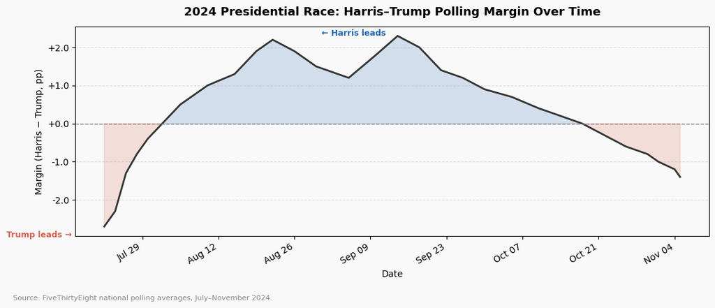

```python
df["margin"] = df["harris"] - df["trump"]

fig, ax = plt.subplots(figsize=(11, 4.5))
fig.patch.set_facecolor(BG)
ax.set_facecolor(BG)

# ── Colored fill above / below zero ──────────────────────────────────────────
ax.fill_between(df["date"], df["margin"], 0,
                where=(df["margin"] >= 0), interpolate=True,
                color=BLUE, alpha=0.18)
ax.fill_between(df["date"], df["margin"], 0,
                where=(df["margin"] < 0), interpolate=True,
                color=RED, alpha=0.18)

ax.plot(df["date"], df["margin"], color="#333333", lw=2)
ax.axhline(0, color=GRAY, lw=1, ls="--")

# ── Direct labels (no legend) ─────────────────────────────────────────────────
peak_row   = df.loc[df["margin"].idxmax()]
trough_row = df.loc[df["margin"].idxmin()]

ax.text(peak_row["date"] - pd.Timedelta(days=14),
        peak_row["margin"] + 0.0,
        "← Harris leads", color=BLUE, fontsize=9, fontweight="bold")

ax.text(trough_row["date"] - pd.Timedelta(days=18),
        trough_row["margin"] - 0.28,
        "Trump leads →", color=RED, fontsize=9, fontweight="bold")

# ── Formatting ────────────────────────────────────────────────────────────────
ax.set_title("2024 Presidential Race: Harris–Trump Polling Margin Over Time",
             fontsize=13, fontweight="bold", pad=12)
ax.set_xlabel("Date", fontsize=10)
ax.set_ylabel("Margin (Harris − Trump, pp)", fontsize=10)
ax.yaxis.set_major_formatter(mticker.FormatStrFormatter("%+.1f"))
ax.xaxis.set_major_formatter(mdates.DateFormatter("%b %d"))
ax.xaxis.set_major_locator(mdates.WeekdayLocator(byweekday=0, interval=2))
plt.xticks(rotation=30, ha="right")
ax.grid(axis="y", ls="--", alpha=0.4)
fig.text(0.01, -0.04, "Source: FiveThirtyEight national polling averages, July–November 2024.",
         fontsize=8, color=GRAY)

plt.tight_layout()
plt.show()
```

Values above zero indicate Harris leading; below zero indicates Trump leading. Harris held a modest national lead from late July through mid-October, after which Trump moved ahead.

## Formatted Summary Table

This table provides exact polling averages at each key event milestone, making precise comparisons easier than reading off a chart.

```python
milestones = [
    ("Jul 22", "Race opens (Biden withdraws)",       "2024-07-22"),
    ("Jul 26", "Harris enters race",                 "2024-07-26"),
    ("Aug 19", "Democratic National Convention",     "2024-08-19"),
    ("Sep 10", "Presidential Debate",                "2024-09-10"),
    ("Oct 14", "VP Debate",                          "2024-10-14"),
    ("Nov 05", "Election Day (final average)",       "2024-11-05"),
]

rows = []
for short_date, label, full_date in milestones:
    row    = df[df["date"] == full_date].iloc[0]
    margin = row["harris"] - row["trump"]
    rows.append({
        "Date":        short_date,
        "Event":       label,
        "Harris (%)": f"{row['harris']:.1f}",
        "Trump (%)": f"{row['trump']:.1f}",
        "Margin (pp)": f"{margin:+.1f}",
        "Leader":     "Harris" if margin > 0 else "Trump",
    })

table_df = pd.DataFrame(rows)

def highlight_leader(row):
    styles = [""] * len(row)
    idx = list(row.index).index("Leader")
    if row["Leader"] == "Harris":
        styles[idx] = f"color: {BLUE}; font-weight: bold"
    else:
        styles[idx] = f"color: {RED}; font-weight: bold"
    return styles

styled = (
    table_df.style
    .apply(highlight_leader, axis=1)
    .set_caption("Table 1. Polling Averages at Key Race Milestones")
    .set_table_styles([
        {"selector": "caption",
         "props": [("font-size", "13px"), ("font-weight", "bold"),
                   ("text-align", "left"), ("padding-bottom", "6px")]},
        {"selector": "th",
         "props": [("background-color", "#e8eef5"), ("font-size", "11px"),
                   ("text-align", "center"), ("border-bottom", "2px solid #aaa")]},
        {"selector": "td",
         "props": [("text-align", "center"), ("font-size", "11px"),
                   ("padding", "5px 10px")]},
        {"selector": "tr:nth-child(even)",
         "props": [("background-color", "#f4f8fc")]},
    ])
    .hide(axis="index")
)

styled
```

Table 1: Table 1. Polling Averages at Key Race Milestones

| Date | Event | Harris (%) | Trump (%) | Margin (pp) | Leader |
| --- | --- | --- | --- | --- | --- |
| Jul 22 | Race opens (Biden withdraws) | 44.1 | 46.8 | -2.7 | Trump |
| Jul 26 | Harris enters race | 44.9 | 46.2 | -1.3 | Trump |
| Aug 19 | Democratic National Convention | 47.0 | 45.1 | +1.9 | Harris |
| Sep 10 | Presidential Debate | 47.1 | 45.3 | +1.8 | Harris |
| Oct 14 | VP Debate | 46.3 | 46.1 | +0.2 | Harris |
| Nov 05 | Election Day (final average) | 47.5 | 48.9 | -1.4 | Trump |

## Reflection

**Annotated Time-Series**

The primary goal of this was to show both candidates’ trajectories in a single readable chart while grounding the trend in real-world events. I chose three annotations — Harris’s entry into the race, the presidential debate, and the VP debate — because these were moments where polling visibly shifted, giving viewers a causal hook rather than an unexplained wiggle. Arrow-style annotations with colored text boxes reinforce which candidate each event benefited or hurt without requiring the viewer to look away to a legend. The shaded uncertainty bands (±0.5 percentage points) acknowledge that polling averages are estimates, not precise measurements. A dashed vertical line for Election Day anchors the time axis conceptually.

**Directly-Labeled Chart**

A margin chart collapses two noisy lines into a single, easier-to-read signal — the gap between candidates. Instead of a legend, I placed “Harris leads ←” and “Trump leads →” as direct text labels at the chart’s peak and trough respectively. This is more honest than a legend because it tells readers *what the value means*, not just who is who. The blue/red fill above and below zero reinforces the directionality at a glance, matching conventional U.S. political color coding.

**Table Design**

The table is designed to complement rather than repeat the charts. While the visualizations show trends, the table provides exact figures at discrete, named moments — information that is difficult to extract accurately from a line chart. Alternating row shading improves readability across six columns. The “Leader” column uses colored bold text (blue for Harris, red for Trump) to make partisan direction immediately legible, consistent with the chart palette. Caption placement and left-alignment follow standard academic table conventions.